# W10 Lab - Neural Networks_v2

## What is a Neural Network?

Neural Networks consist of the following components

- An input layer, x
- An arbitrary amount of hidden layers
- An output layer, ŷ
- A set of weights and biases between each layer, W and b
- A choice of activation function for each hidden layer, σ. In this tutorial, we’ll use a Sigmoid activation function.

The diagram below shows the architecture of a 2-layer Neural Network (note that the input layer is typically excluded when counting the number of layers in a Neural Network)

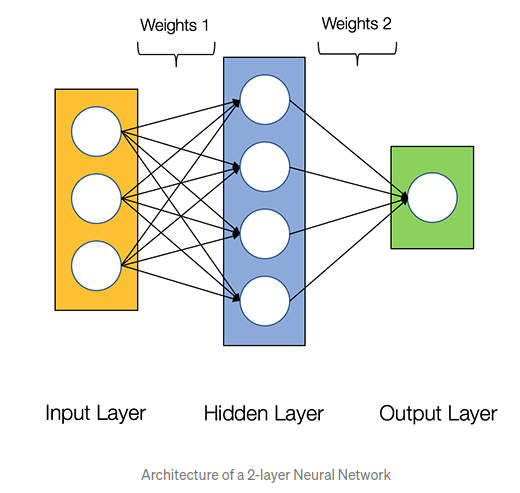

Creating a Neural Network class in Python is easy.

```python
class NeuralNetwork:
    def __init__(self, x, y):
        self.input = x
        self.weights1 = np.random.rand(self.input.shape[1], 4)
        self.weights2 = np.random.rand(4, 1)
        self.y = y
        self.output = np.zeros(y.shape)
```

## **Training the Neural Network**

Naturally, the right values for the weights and biases determines the strength of the predictions. The process of fine-tuning the weights and biases from the input data is known as training the Neural Network.

Each iteration of the training process consists of the following steps:

- Calculating the predicted output ŷ, known as feedforward
- Updating the weights and biases, known as backpropagation The sequential graph below illustrates the process.

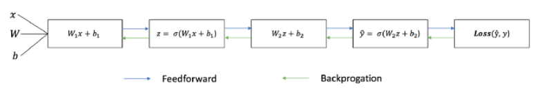

### **Feedforward**

Let’s add a feedforward function in our python code to do exactly that. Note that for simplicity, we have assumed the biases to be 0.

```python
class NeuralNetwork:
    def __init__(self, x, y):
        self.input = x
        self.weights1 = np.random.rand(self.input.shape[1], 4)
        self.weights2 = np.random.rand(4, 1)
        self.y = y
        self.output = np.zeros(y.shape)

    def feedforward(self):
        self.layer1 = sigmoid(np.dot(self.input, self.weights1))
        self.output = sigmoid(np.dot(self.layer1, self.weights2))
```

However, we still need a way to evaluate the “goodness” of our predictions (i.e. how far off are our predictions)? The Loss Function allows us to do exactly that.

### **Loss Function**

There are many available loss functions, and the nature of our problem should dictate our choice of loss function. In this tutorial, we’ll use a simple sum-of-squares error as our loss function.

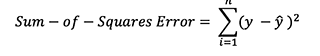

That is, the sum-of-squares error is simply the sum of the difference between each predicted value and the actual value. The difference is squared so that we measure the absolute value of the difference.

Our goal in training is to find the best set of weights and biases that minimizes the loss function.

### Backpropagation

Now that we’ve measured the error of our prediction (loss), we need to find a way to propagate the error back, and to update our weights and biases.

Recall from calculus that the derivative of a function is simply the slope of the function.

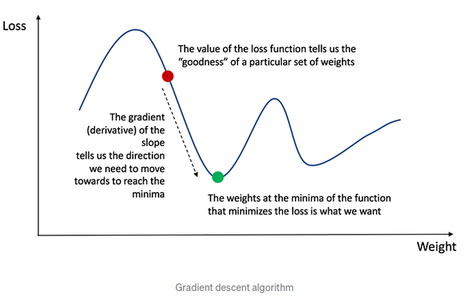

If we have the derivative, we can simply update the weights and biases by increasing/reducing with it(refer to the diagram above). This is known as gradient descent.

However, we can’t directly calculate the derivative of the loss function with respect to the weights and biases because the equation of the loss function does not contain the weights and biases. Therefore, we need the chain rule to help us calculate it.

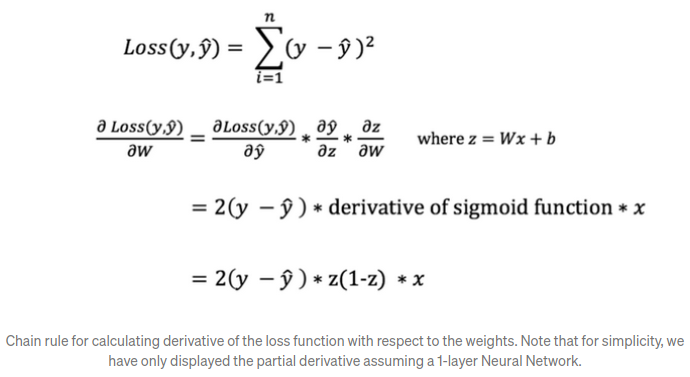

Phew! That was ugly but it allows us to get what we needed — the derivative (slope) of the loss function with respect to the weights, so that we can adjust the weights accordingly.

Now that we have that, let’s add the backpropagation function into our python code.

```python
class NeuralNetwork:
    def __init__(self, x, y):
        self.input = x
        self.weights1 = np.random.rand(self.imput.shape[1], 4)
        self.weights2 = np.random.rand(4, 1)
        self.y = y
        self.output = np.zeros(y.shape)

    def feedforward(self):
        self.layer1 = sigmoid(np.dot(self.input, self.weights1))
        self.output = sigmoid(np.dot(self.layer1, self.weights2))

    def backprop(self):
        # application of the chain rule to find derivative of the
        # loss function with respect to weights1 and weights2
        d_weights2 = np.dot(self.layer1.T, (2*(self.y - self.output)
                    * sigmoid_derivative(self.output)))
        d_weights1 = np.dot(self.input.T, (np.dot(2*(self.y - self.output)
                    * sigmoid_derivative(self.output), self.weights2.T) *
                    sigmoid_derivative(self.layer1)))

        # update the weights with the derivative (slope) of the loss function
        self.weights1 += d_weights1
        self.weights2 += d_weights2
```

For a deeper understanding of the application of calculus and the chain rule in backpropagation, it is strongly recommended to watch this tutorial by 3Blue1Brown. https://youtu.be/tIeHLnjs5U8

## **Putting it all together**

Now that we have our complete python code for doing feedforward and backpropagation, let’s apply our Neural Network on an example and see how well it does.

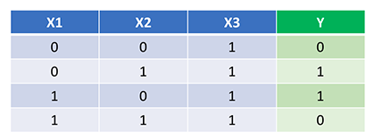

Our Neural Network should learn the ideal set of weights to represent this function. Note that it isn’t exactly trivial for us to work out the weights just by inspection alone.

Let’s train the Neural Network for 1500 iterations and see what happens. Looking at the loss per iteration graph below, we can clearly see the loss monotonically decreasing towards a minimum. This is consistent with the gradient descent algorithm that we’ve discussed earlier.

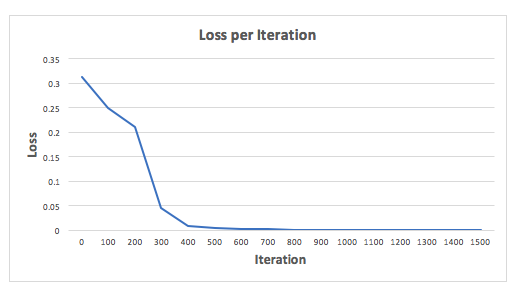

Let’s look at the final prediction (output) from the Neural Network after 1500 iterations.

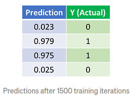

We did it! Our feedforward and backpropagation algorithm trained the Neural Network successfully and the predictions converged on the true values.

Note that there’s a slight difference between the predictions and the actual values. This is desirable, as it prevents overfitting and allows the Neural Network to generalize better to unseen data.

# Testing Code

```python
import numpy as np
```

```python
# Each row is a training example, each column is a feature  [X1, X2, X3]
X = np.array(([0,0,1],[0,1,1],[1,0,1],[1,1,1]), dtype=float)
y = np.array(([0],[1],[1],[0]), dtype=float)
```

```python
print(X)
print('Shape of X =', X.shape)
print(10*'-')
print(y)
print('Shape of y =', y.shape)
```

```
[[0. 0. 1.]
 [0. 1. 1.]
 [1. 0. 1.]
 [1. 1. 1.]]
Shape of X = (4, 3)
----------
[[0.]
 [1.]
 [1.]
 [0.]]
Shape of y = (4, 1)
```

**Define useful functions**

```python
# Activation function
def sigmoid(t):
    return 1/(1+np.exp(-t))

# Derivative of sigmoid
def sigmoid_derivative(p):
    return p * (1 - p)

# Class definition
class NeuralNetwork:
    def __init__(self, x,y):
        self.input = x
        self.weights1= np.random.rand(self.input.shape[1],4) # considering we have 4 nodes in the hidden layer
        self.weights2 = np.random.rand(4,1)
        self.y = y
        self.output = np. zeros(y.shape)

    def feedforward(self):
        self.layer1 = sigmoid(np.dot(self.input, self.weights1))
        self.layer2 = sigmoid(np.dot(self.layer1, self.weights2))
        return self.layer2

    def backprop(self):
        d_weights2 = np.dot(self.layer1.T, 2*(self.y -self.output)*sigmoid_derivative(self.output))
        d_weights1 = np.dot(self.input.T, np.dot(2*(self.y - self.output)*sigmoid_derivative(self.output),
                                                 self.weights2.T)*sigmoid_derivative(self.layer1))

        self.weights1 += d_weights1
        self.weights2 += d_weights2

    def train(self):
        self.output = self.feedforward()
        self.backprop()
```

```python
print ("Input: \n" + str(X))
print ("\nActual Output: \n" + str(y))
```

```
Input:
[[0. 0. 1.]
 [0. 1. 1.]
 [1. 0. 1.]
 [1. 1. 1.]]

Actual Output:
[[0.]
 [1.]
 [1.]
 [0.]]
```

```python
NN = NeuralNetwork(X,y)

loss_lst = []
for i in range(1000): # trains the NN 1,000 times
    loss = np.mean(np.square(y - NN.feedforward()))
    loss_lst.append(loss)

    if i % 100 ==0:
        print ("for iteration # " + str(i) + "\n")
        print ("Predicted Output: \n" + str(NN.feedforward()))
        print ("Loss: \n" + str(loss)) # mean sum squared loss
        print ("----------------\n")

    NN.train()
```

```
for iteration # 0

Predicted Output:
[[0.72001372]
 [0.74936188]
 [0.74634873]
 [0.7693667 ]]
Loss:
0.3093758260123646
----------------

for iteration # 100

Predicted Output:
[[0.49247652]
 [0.49967294]
 [0.51487853]
 [0.51430988]]
Loss:
0.24817944402937742
----------------

for iteration # 200

Predicted Output:
[[0.27408939]
 [0.5730469 ]
 [0.63097214]
 [0.55849634]]
Loss:
0.17637841495913634
----------------

for iteration # 300

Predicted Output:
[[0.11281432]
 [0.8267213 ]
 [0.84536055]
 [0.19613762]]
```

[output cut: 54 more lines]

```
 [0.03846574]]
Loss:
0.0011079775214809333
----------------

for iteration # 900

Predicted Output:
[[0.02113222]
 [0.96705325]
 [0.97053108]
 [0.03461735]]
Loss:
0.0008997094113595929
----------------
```

**Loss plot**

[figure not shown]

```python
import matplotlib.pyplot as plt

plt.plot(np.arange(1, len(loss_lst)+1), loss_lst)
plt.xlabel('num of iteration')
plt.ylabel('Loss');
```